# EDA

```python
import numpy as np # linear algebra
import pandas as pd # data processing, CSV file I/O (e.g. pd.read_csv)
import os
from glob import glob
%matplotlib inline
import matplotlib.pyplot as plt
import seaborn as sns
from itertools import chain
from skimage import io
import scipy.stats



##Import any other packages you may need here
```

EDA is open-ended, and it is up to you to decide how to look at different ways to slice and dice your data. A good starting point is to look at the requirements for the FDA documentation in the final part of this project to guide (some) of the analyses you do.

This EDA should also help to inform you of how pneumonia looks in the wild. E.g. what other types of diseases it's commonly found with, how often it is found, what ages it affects, etc.

Note that this NIH dataset was not specifically acquired for pneumonia. So, while this is a representation of 'pneumonia in the wild,' the prevalence of pneumonia may be different if you were to take only chest x-rays that were acquired in an ER setting with suspicion of pneumonia.

Perform the following EDA:

- The patient demographic data such as gender, age, patient position,etc. (as it is available)
- The x-ray views taken (i.e. view position)
- The number of cases including:
  - number of pneumonia cases,
  - number of non-pneumonia cases
- The distribution of other diseases that are comorbid with pneumonia
- Number of disease per patient
- Pixel-level assessments of the imaging data for healthy & disease states of interest (e.g. histograms of intensity values) and compare distributions across diseases.

Note: use full NIH data to perform the first a few EDA items and use `sample_labels.csv` for the pixel-level assassements.

Also, **describe your findings and how will you set up the model training based on the findings.**

```python
## Below is some helper code to read data for you.
## Load NIH data
all_xray_df = pd.read_csv('/data/Data_Entry_2017.csv')
all_xray_df.head(5)
```

|  | Image Index | Finding Labels | Follow-up # | Patient ID | Patient Age | Patient Gender | View Position | OriginalImage[Width | Height] | OriginalImagePixelSpacing[x | y] | Unnamed: 11 |
| --- | --- | --- | --- | --- | --- | --- | --- | --- | --- | --- | --- | --- |
| 0 | 00000001_000.png | Cardiomegaly | 0 | 1 | 58 | M | PA | 2682 | 2749 | 0.143 | 0.143 | NaN |
| 1 | 00000001_001.png | Cardiomegaly\|Emphysema | 1 | 1 | 58 | M | PA | 2894 | 2729 | 0.143 | 0.143 | NaN |
| 2 | 00000001_002.png | Cardiomegaly\|Effusion | 2 | 1 | 58 | M | PA | 2500 | 2048 | 0.168 | 0.168 | NaN |
| 3 | 00000002_000.png | No Finding | 0 | 2 | 81 | M | PA | 2500 | 2048 | 0.171 | 0.171 | NaN |
| 4 | 00000003_000.png | Hernia | 0 | 3 | 81 | F | PA | 2582 | 2991 | 0.143 | 0.143 | NaN |

```python
## Load 'sample_labels.csv' data for pixel level assessments
sample_df = pd.read_csv('sample_labels.csv')
sample_df.head(5)
```

|  | Image Index | Finding Labels | Follow-up # | Patient ID | Patient Age | Patient Gender | View Position | OriginalImageWidth | OriginalImageHeight | OriginalImagePixelSpacing_x | OriginalImagePixelSpacing_y |
| --- | --- | --- | --- | --- | --- | --- | --- | --- | --- | --- | --- |
| 0 | 00000013_005.png | Emphysema\|Infiltration\|Pleural_Thickening\|Pneu... | 5 | 13 | 060Y | M | AP | 3056 | 2544 | 0.139 | 0.139 |
| 1 | 00000013_026.png | Cardiomegaly\|Emphysema | 26 | 13 | 057Y | M | AP | 2500 | 2048 | 0.168 | 0.168 |
| 2 | 00000017_001.png | No Finding | 1 | 17 | 077Y | M | AP | 2500 | 2048 | 0.168 | 0.168 |
| 3 | 00000030_001.png | Atelectasis | 1 | 30 | 079Y | M | PA | 2992 | 2991 | 0.143 | 0.143 |
| 4 | 00000032_001.png | Cardiomegaly\|Edema\|Effusion | 1 | 32 | 055Y | F | AP | 2500 | 2048 | 0.168 | 0.168 |

```python
#function to plot gender demographics
def gender(df):
    df['Patient Gender'].value_counts().plot(kind='bar')
    plt.xlabel('Gender')
    plt.ylabel('Number of People')
    plt.title('Gender Distribution in Dataset')

    return df['Patient Gender'].value_counts()
```

```
M    63340
F    48780
Name: Patient Gender, dtype: int64
```

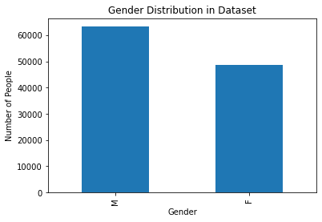

```python
#invoking gender distribution fnc
gender_distribution = gender(all_xray_df)
gender_distribution
```

```python
#There is a very slight imbalance of genders with 63340 male and 48780 female
```

```python
#There seem to be some unrealistic patient ages
all_xray_df[all_xray_df['Patient Age']>100]['Patient Age']
```

```
20852     412
46965     414
48284     148
55742     148
58650     150
62929     149
74884     152
78795     151
84810     411
85404     412
86264     413
91369     412
95794     153
98495     154
101194    155
104590    155
Name: Patient Age, dtype: int64
```

```python
#set these values to NaN
all_xray_df.replace(all_xray_df[all_xray_df['Patient Age']>100]['Patient Age'].values,np.nan, inplace = True)
```

```python
#confirm that no unrealistic values remain
all_xray_df[all_xray_df['Patient Age']>100]['Patient Age']
```

```
Series([], Name: Patient Age, dtype: float64)
```

```python
#defining age distribution fnc
def age(df):
    plt.hist(df['Patient Age'], bins = 10,)
    plt.xlabel('age')
    plt.ylabel('Number of People')
    plt.title('Age Distribution')
```

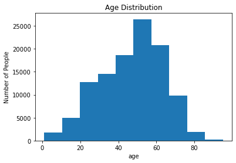

```python
#invoking age distributon fnc
age(all_xray_df)
```

```python
#Dataset contains samples of ages ranging from 2 all the way to almost 100, with a a majority around the 50-60 yr old age
```

```python
# def fnc to show position distribution
def image_pos(df):
    df['View Position'].value_counts().plot(kind='bar')
    plt.xlabel('Image Position')
    plt.ylabel('Number of People')
    plt.title('Image Position Distribution')

    return df['View Position'].value_counts()
```

```
PA    67310
AP    44810
Name: View Position, dtype: int64
```

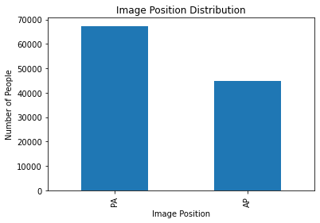

```python
#invoking position distribution fnc
image_position_distribution = image_pos(all_xray_df)
image_position_distribution
```

```python
#Dataset contains both PA and AP image position
```

```python
#split the finding labels into individual columns
def split_labels(df):
    labels = np.unique(list(chain(*df['Finding Labels'].map(lambda x: x.split('|')).tolist())))
    for i in labels:
        df[i] = df['Finding Labels'].map(lambda y: 1.0 if i in y else 0)
```

```python
#invoke function to generate columns for individual diseases
split_labels(all_xray_df)
```

```python
all_xray_df.shape
```

```
(112120, 27)
```

```python
#function plots distribution of +ve/-ve pneumonia cases. 1 is positive, 0 is negative
def pneumonia_cases(df):
    df['Pneumonia'].value_counts().plot(kind='bar')
    plt.xlabel('Presence of Pneumonia(0 is negative 1 is postive)')
    plt.ylabel('Number of People')
    plt.title('Presence of Pneumonia in the Dataset')

    return (df['Pneumonia'].value_counts()[0], df['Pneumonia'].value_counts()[1])
```

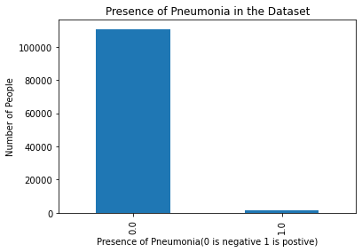

```python
#invoke function to calculate no. of pneumonia cases
negative_pneumonia, positive_pneumonia = pneumonia_cases(all_xray_df)
```

```python
#Dataset has 1431 cases of pneumonia
positive_pneumonia
```

```
1431
```

```python
#ratio of +ve/-ve cases is 1.3%
ratio_pneumonia_cases = positive_pneumonia/negative_pneumonia*100
ratio_pneumonia_cases
```

```
1.2928113904724048
```

```python
#getting labels of different possible diseases
labels = np.unique(list(chain(*all_xray_df['Finding Labels'].map(lambda x: x.split('|')).tolist())))
labels = labels.tolist()

labels
```

```
['Atelectasis',
 'Cardiomegaly',
 'Consolidation',
 'Edema',
 'Effusion',
 'Emphysema',
 'Fibrosis',
 'Hernia',
 'Infiltration',
 'Mass',
 'No Finding',
 'Nodule',
 'Pleural_Thickening',
 'Pneumonia',
 'Pneumothorax']
```

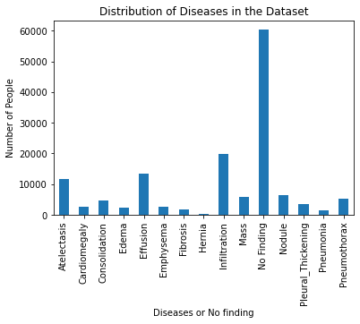

```python
all_xray_df[labels].sum().plot(kind = 'bar')
plt.xlabel('Diseases or No finding')
plt.ylabel('Number of People')
plt.title('Distribution of Diseases in the Dataset')
plt.show()
```

```python
# No Finding is by far the most common diagnosis, followed my infiltration and effusion
```

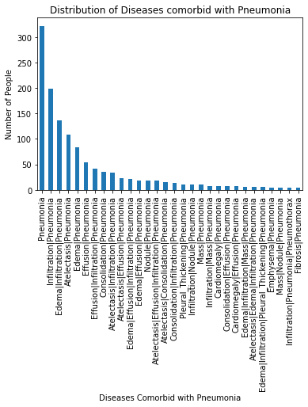

```python
#determine the distribution of diseases comorbid with Pneumonia. Plotting the top 30 combinations
all_xray_df[all_xray_df.Pneumonia == 1]['Finding Labels'].value_counts()[0:30].plot(kind = 'bar')
plt.xlabel('Diseases Comorbid with Pneumonia')
plt.ylabel('Number of People')
plt.title('Distribution of Diseases comorbid with Pneumonia')
disease_conjunction_pneumonia = all_xray_df[all_xray_df.Pneumonia == 1]['Finding Labels'].value_counts()
```

```python
#Most common comorbodies are 'infiltration', 'edema', 'atelectasis', 'effusion', 'consolidation'
```

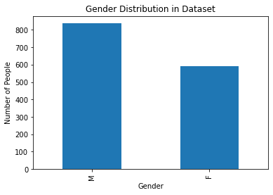

```python
#distribution of gender with positive pneumonia cases
pneumonia_gender_distribution = gender(all_xray_df[all_xray_df.Pneumonia == 1])
```

```python
#Gender distribution amongst pneumonia patients is similar to the main dataset
```

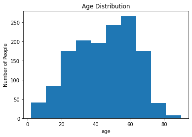

```python
#age distribution with positive pneumonia cases
age(all_xray_df[all_xray_df.Pneumonia == 1])
```

```python
#Age distribution amongst pneumonia patients is similar to the main dataset, with  majority of patients being in the 50-60 age range
```

```
AP    801
PA    630
Name: View Position, dtype: int64
```

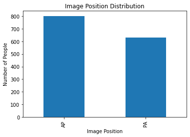

```python
#position distribution for +ve pneumonia cases
pneumonia_position_distribution = image_pos(all_xray_df[all_xray_df.Pneumonia == 1])
pneumonia_position_distribution
```

```python
#getting labels of different possible diseases
labels = np.unique(list(chain(*all_xray_df['Finding Labels'].map(lambda x: x.split('|')).tolist())))
labels = labels.tolist()
labels.remove('No Finding')
labels
```

```
['Atelectasis',
 'Cardiomegaly',
 'Consolidation',
 'Edema',
 'Effusion',
 'Emphysema',
 'Fibrosis',
 'Hernia',
 'Infiltration',
 'Mass',
 'Nodule',
 'Pleural_Thickening',
 'Pneumonia',
 'Pneumothorax']
```

```python
#fnc to determine number of diseases per person
def diseases_per_person(df,labels):
    total_disease = df[labels].sum(axis = 1)
    avg_disease = np.mean(total_disease)
    return total_disease, avg_disease
```

```python
#number of diseases for each patient and avg number of diseases per patient
num_disease_person, avg_disease_person = diseases_per_person(all_xray_df, labels)
print(avg_disease_person)
```

```
0.7240099892971816
```

```python
#An average of 0.72 diseased diagnosed per person in the dataset
```

```python
#INTENSITY VALUE ANALYSIS
#INTENSITY VALUE ANALYSIS
#INTENSITY VALUE ANALYSIS
```

```python
#split the finding labels into individual columns for intenisty val dataset
split_labels(sample_df)
```

```python
sample_df.shape
```

```
(5606, 26)
```

```python
#Get image paths for all images in sample_df
image_path = [glob(f'/data/images*/*/{i}')[0] for i in sample_df['Image Index'].values]
```

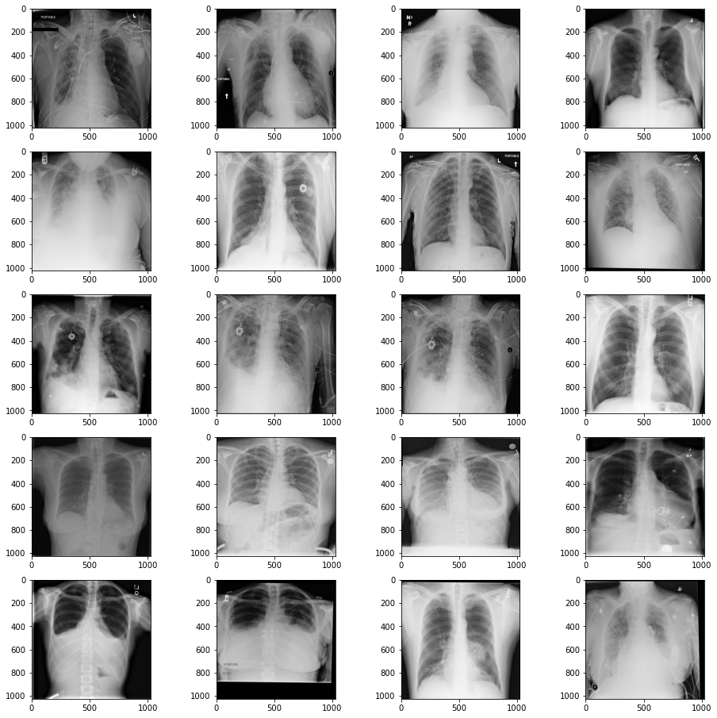

```python
#displaying first 20 imgs in the sample set
fig, m_axs = plt.subplots(5,4, figsize = (16, 16))
m_axs = m_axs.flatten()
imgs = image_path


for img, ax in zip(imgs, m_axs):
    img = io.imread(img)
    ax.imshow(img,cmap='gray')
```

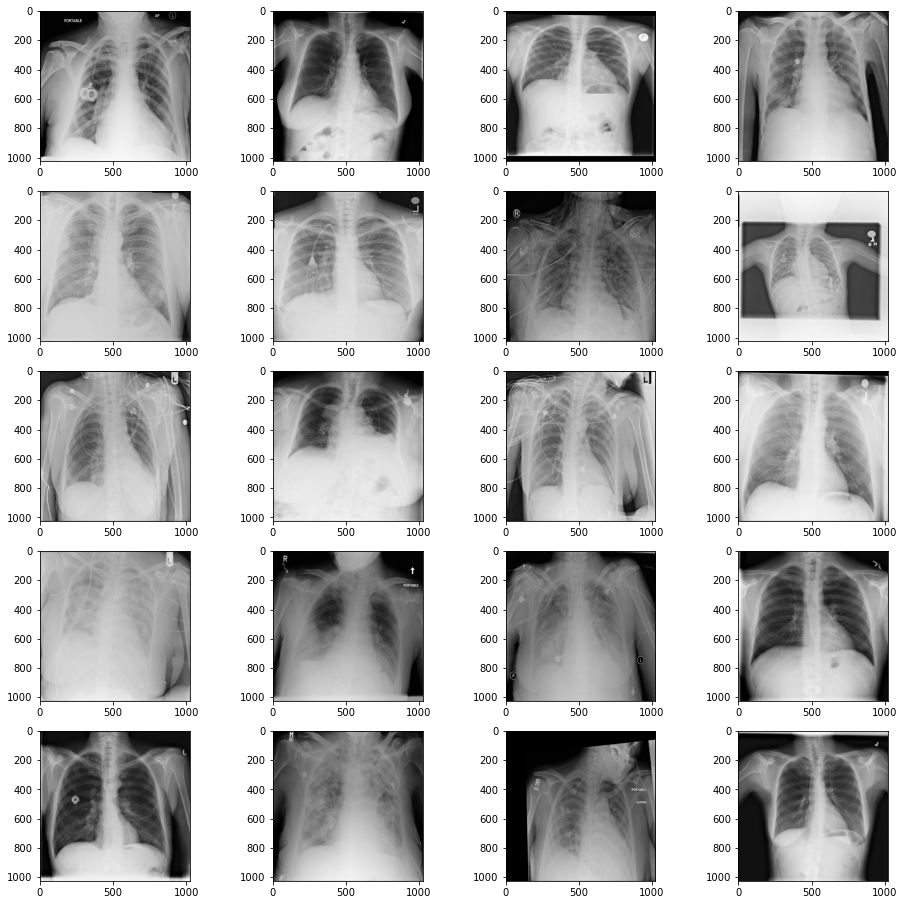

```python
#display 20 imgs that have pneumonia
fig, m_axs = plt.subplots(5,4, figsize = (16, 16))
m_axs = m_axs.flatten()
pneumonia_imgs = sample_df[sample_df.Pneumonia==1]['Image Index']
pneumonia_image_path = [glob(f'/data/images*/*/{i}')[0] for i in pneumonia_imgs]

for img, ax in zip(pneumonia_image_path, m_axs):
    img = io.imread(img)
    ax.imshow(img,cmap='gray')
```

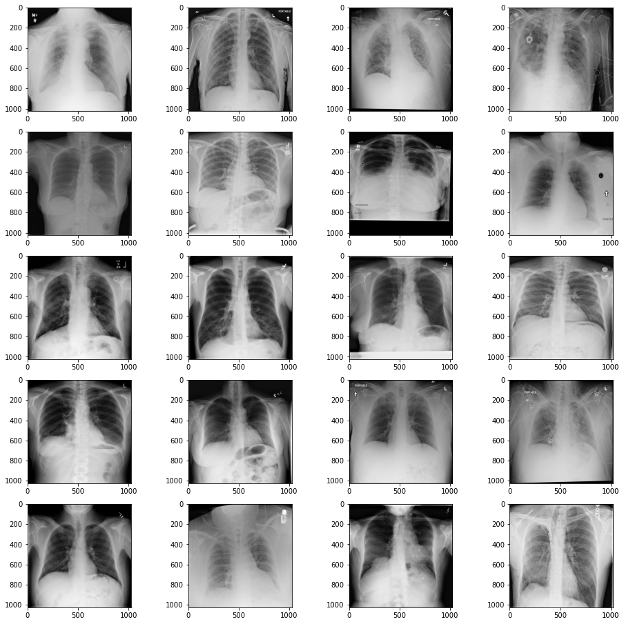

```python
#display 20 imgs that have no finding
fig, m_axs = plt.subplots(5,4, figsize = (16, 16))
m_axs = m_axs.flatten()
healthy_imgs = sample_df[sample_df['No Finding']==1]['Image Index']
healthy_image_path = [glob(f'/data/images*/*/{i}')[0] for i in healthy_imgs]

for img, ax in zip(healthy_image_path, m_axs):
    img = io.imread(img)
    ax.imshow(img,cmap='gray')
```

```python
#Generating img paths for pneumonia and diseases mose frequently occuring with pneumonia but
infiltration_imgs = sample_df[(sample_df.Infiltration==1) & (sample_df.Pneumonia==0)]['Image Index']
infiltration_image_path = [glob(f'/data/images*/*/{i}')[0] for i in infiltration_imgs]

edema_imgs = sample_df[(sample_df.Edema==1) & (sample_df.Pneumonia==0)]['Image Index']
edema_image_path = [glob(f'/data/images*/*/{i}')[0] for i in edema_imgs]

atelectasis_imgs = sample_df[(sample_df.Atelectasis==1) & (sample_df.Pneumonia==0)]['Image Index']
atelectasis_image_path = [glob(f'/data/images*/*/{i}')[0] for i in atelectasis_imgs]

effusion_imgs = sample_df[(sample_df.Effusion==1) & (sample_df.Pneumonia==0)]['Image Index']
effusion_image_path = [glob(f'/data/images*/*/{i}')[0] for i in effusion_imgs]

consolidation_imgs = sample_df[(sample_df.Consolidation==1) & (sample_df.Pneumonia==0)]['Image Index']
consolidation_image_path = [glob(f'/data/images*/*/{i}')[0] for i in consolidation_imgs]
```

```python
#fnc to plot intesity values
def multiple_intense_val(path):
    image = io.imread(path)
    plt.hist(image.ravel(),bins=256)
    plt.legend(['pneumonia', 'infiltration', 'edema', 'atelectasis', 'effusion', 'consolidation'])
```

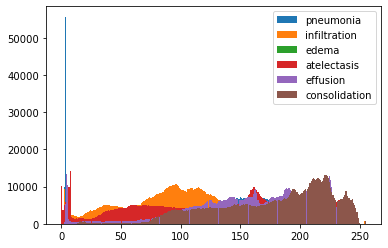

```python
#plotting intensity value of pneumonia and diseases most common with pneumonia(single cases)
multiple_intense_val(pneumonia_image_path[0])
multiple_intense_val(infiltration_image_path[0])
multiple_intense_val(edema_image_path[0])
multiple_intense_val(atelectasis_image_path[0])
multiple_intense_val(effusion_image_path[0])
multiple_intense_val(consolidation_image_path[0])
```

```python
#Based on above intensity value it makes sense to have a threshold of around 15 in order to not consider background
thresh = 15
boundary = 254
```

```python
#Generate intensity vals for positive Pneumonia cases. There also seems to be a spike at high intensity
#(this proabably is the boundary of the image)
def cumulative_intensity(disease_img_path, thresh, boundary):
    img_intensities = []
    for i in disease_img_path:
        img = io.imread(i)

        img_intensities.extend(img[(img > thresh) & (img < boundary)].tolist())
    x = plt.hist(img_intensities,bins=256)

    return img_intensities
```

```python
##GET INTENSITY VALUES FOR DIFFERENT DISEASES
```

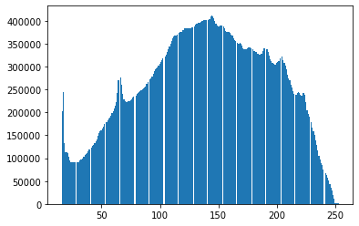

```python
pneumonia_intensities = cumulative_intensity(pneumonia_image_path, thresh, boundary)
```

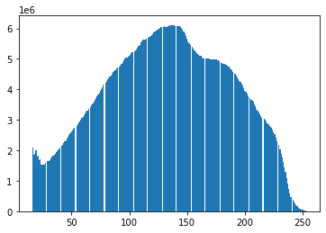

```python
infiltration_intensities = cumulative_intensity(infiltration_image_path, thresh, boundary)
```

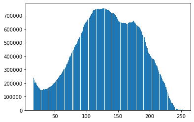

```python
edema_intensities = cumulative_intensity(edema_image_path, thresh, boundary)
```

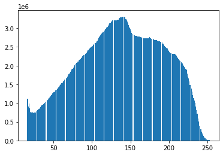

```python
atelectasis_intensities = cumulative_intensity(atelectasis_image_path, thresh, boundary)
```

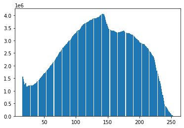

```python
effusion_intensities = cumulative_intensity(effusion_image_path, thresh, boundary)
```

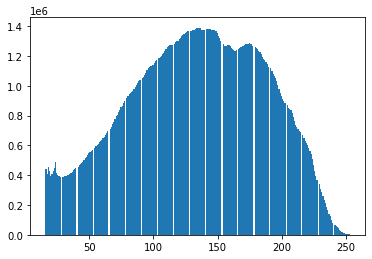

```python
consolidation_intensities = cumulative_intensity(consolidation_image_path, thresh, boundary)
```

```python
pneumonia_mode = scipy.stats.mode(pneumonia_intensities)[0][0]
infiltration_mode = scipy.stats.mode(infiltration_intensities)[0][0]
edema_mode = scipy.stats.mode(edema_intensities)[0][0]
atelectasis_mode = scipy.stats.mode(atelectasis_intensities)[0][0]
effusion_mode = scipy.stats.mode(effusion_intensities)[0][0]
consolidation_mode = scipy.stats.mode(consolidation_intensities)[0][0]
```

```python
print(pneumonia_mode, infiltration_mode, edema_mode, atelectasis_mode, effusion_mode, consolidation_mode)
```

```
144 136 128 141 142 136
```

```python
#comparing first 10 pneumonia diagnoses intensity mode with the general pneumonia population intensity mode
for path in pneumonia_image_path[0:10]:

    img = io.imread(path)

    img_mask = (img > thresh) & (img < boundary)

    mode = scipy.stats.mode(img[img_mask])[0][0]

    pneumonia_delta = np.abs(mode - pneumonia_mode)
    infiltration_delta = np.abs(mode - infiltration_mode)
    edema_delta = np.abs(mode - edema_mode)
    atelectasis_delta = np.abs(mode - atelectasis_mode)
    effusion_delta = np.abs(mode - effusion_mode)
    consolidation_delta = np.abs(mode - consolidation_mode)

    min_mode = min([pneumonia_delta, infiltration_delta, edema_delta, atelectasis_delta, effusion_delta, consolidation_delta ])

    if min_mode == pneumonia_delta:
        print("Correct Label")
    else:
        print("Incorrect Label")
```

```
Correct Label
Correct Label
Incorrect Label
Correct Label
Correct Label
Correct Label
Incorrect Label
Incorrect Label
Correct Label
Correct Label
```

```python
#As seen above, we only have 70% accuracy on 10 labels i.e hard to differentiate based on intensity values
#between pneumonia and diseases it most commonly occurs with, such as inflitration,
#edema, atelectasis, effusion and consolidation
```